# NYC Yellow Taxi - MongoDB Medallion Architecture

**Big Data: Tools and Techniques - Spring 2026**

This notebook demonstrates a complete Big Data pipeline using **MongoDB** as the distributed NoSQL database, applied to the **NYC Yellow Taxi Trip** dataset (January 2024, ~2.96M rows × 19 columns) from the NYC Taxi & Limousine Commission.

## Why MongoDB?

- **Document model** is ideal for semi-structured trip records with optional fields (e.g. `Airport_fee`, `congestion_surcharge`).
- **Aggregation Pipeline** is a powerful, declarative way to build the Gold layer.
- **Horizontal scalability** via sharding makes it appropriate for high-volume taxi telemetry that grows monthly.
- **Indexes** on pickup datetime and location IDs enable fast time-series and geospatial-style analytics.

## Medallion Architecture

| Layer | Purpose | Implementation |
| --- | --- | --- |
| **Bronze** | Raw data ingestion | Parquet → MongoDB collection `taxi_bronze` |
| **Silver** | Cleaned & validated | Filter nulls, duplicates, outliers → `taxi_silver` |
| **Gold** | Aggregated insights | Aggregation Pipelines → `taxi_gold_*` collections + viz |

## 1. Setup

```python
import os
import sys
import time
import pandas as pd
import numpy as np
import matplotlib.pyplot as plt
import seaborn as sns
from pymongo import MongoClient, ASCENDING

sns.set_theme(style="whitegrid", palette="viridis")
plt.rcParams["figure.figsize"] = (11, 5)
plt.rcParams["figure.dpi"] = 110

DATA_PATH = "data/yellow_tripdata_2024-01.parquet"
VIZ_DIR   = "visualizations"
os.makedirs(VIZ_DIR, exist_ok=True)

SAMPLE_SIZE = 250_000
RANDOM_SEED = 42
```

## 2. Connect to MongoDB

```python
client = MongoClient("mongodb://localhost:27017", serverSelectionTimeoutMS=5000)
client.admin.command("ping")
print("Connected to MongoDB:", client.server_info()["version"])

db = client["nyc_taxi_dw"]
bronze = db["taxi_bronze"]
silver = db["taxi_silver"]
```

```
Connected to MongoDB: 8.2.7
```

## 3. Bronze Layer - Raw Ingestion

Read the parquet file produced by NYC TLC and load a sample of records as-is into MongoDB. The Bronze layer is the immutable source-of-truth copy of the raw data.

```python
t0 = time.time()
df_full = pd.read_parquet(DATA_PATH)
print(f"Raw parquet loaded in {time.time()-t0:.1f}s")
print(f"Full dataset shape: {df_full.shape[0]:,} rows x {df_full.shape[1]} columns")
print("\nColumns and dtypes:")
print(df_full.dtypes)
df_full.head()
```

```
Raw parquet loaded in 0.3s
Full dataset shape: 2,964,624 rows x 19 columns

Columns and dtypes:
VendorID                          int32
tpep_pickup_datetime     datetime64[us]
tpep_dropoff_datetime    datetime64[us]
passenger_count                 float64
trip_distance                   float64
RatecodeID                      float64
store_and_fwd_flag                  str
PULocationID                      int32
DOLocationID                      int32
payment_type                      int64
fare_amount                     float64
extra                           float64
mta_tax                         float64
tip_amount                      float64
tolls_amount                    float64
improvement_surcharge           float64
total_amount                    float64
congestion_surcharge            float64
Airport_fee                     float64
dtype: object
```

|  | VendorID | tpep_pickup_datetime | tpep_dropoff_datetime | passenger_count | trip_distance | RatecodeID | store_and_fwd_flag | PULocationID | DOLocationID | payment_type | fare_amount | extra | mta_tax | tip_amount | tolls_amount | improvement_surcharge | total_amount | congestion_surcharge | Airport_fee |
| --- | --- | --- | --- | --- | --- | --- | --- | --- | --- | --- | --- | --- | --- | --- | --- | --- | --- | --- | --- |
| 0 | 2 | 2024-01-01 00:57:55 | 2024-01-01 01:17:43 | 1.0 | 1.72 | 1.0 | N | 186 | 79 | 2 | 17.7 | 1.0 | 0.5 | 0.00 | 0.0 | 1.0 | 22.70 | 2.5 | 0.0 |
| 1 | 1 | 2024-01-01 00:03:00 | 2024-01-01 00:09:36 | 1.0 | 1.80 | 1.0 | N | 140 | 236 | 1 | 10.0 | 3.5 | 0.5 | 3.75 | 0.0 | 1.0 | 18.75 | 2.5 | 0.0 |
| 2 | 1 | 2024-01-01 00:17:06 | 2024-01-01 00:35:01 | 1.0 | 4.70 | 1.0 | N | 236 | 79 | 1 | 23.3 | 3.5 | 0.5 | 3.00 | 0.0 | 1.0 | 31.30 | 2.5 | 0.0 |
| 3 | 1 | 2024-01-01 00:36:38 | 2024-01-01 00:44:56 | 1.0 | 1.40 | 1.0 | N | 79 | 211 | 1 | 10.0 | 3.5 | 0.5 | 2.00 | 0.0 | 1.0 | 17.00 | 2.5 | 0.0 |
| 4 | 1 | 2024-01-01 00:46:51 | 2024-01-01 00:52:57 | 1.0 | 0.80 | 1.0 | N | 211 | 148 | 1 | 7.9 | 3.5 | 0.5 | 3.20 | 0.0 | 1.0 | 16.10 | 2.5 | 0.0 |

```python
# Sample for MongoDB ingestion
df_sample = df_full.sample(n=SAMPLE_SIZE, random_state=RANDOM_SEED).reset_index(drop=True)
print(f"Sample to ingest: {df_sample.shape[0]:,} rows x {df_sample.shape[1]} columns")
```

```
Sample to ingest: 250,000 rows x 19 columns
```

```python
# Insert into Bronze (drop & re-create for idempotency)
bronze.drop()
records = df_sample.to_dict(orient="records")

t0 = time.time()
bronze.insert_many(records, ordered=False)
print(f"Bronze insert: {bronze.estimated_document_count():,} docs in {time.time()-t0:.1f}s")

# Indexes for downstream queries
bronze.create_index([("tpep_pickup_datetime", ASCENDING)])
bronze.create_index([("PULocationID", ASCENDING)])
print("Indexes:", [ix['name'] for ix in bronze.list_indexes()])
```

```
Bronze insert: 250,000 docs in 1.8s
```

```
Indexes: ['_id_', 'tpep_pickup_datetime_1', 'PULocationID_1']
```

### 3a. Row & Column counts via MongoDB queries

```python
bronze_count = bronze.count_documents({})
sample_doc   = bronze.find_one()
bronze_cols  = [k for k in sample_doc.keys() if k != "_id"]
print(f"Bronze rows   : {bronze_count:,}")
print(f"Bronze columns: {len(bronze_cols)}  -> {bronze_cols}")
```

[output not shown]

## 4. Silver Layer - Data Cleaning

Apply a series of validation rules using MongoDB aggregation `$match` stages and write the result to `taxi_silver`.

**Rules:**

1. Drop documents with any null in critical fields (`passenger_count`, `trip_distance`, `total_amount`, `tpep_pickup_datetime`, `tpep_dropoff_datetime`).
2. Drop trips with non-positive distance, fare, or passenger_count.
3. Drop trips where dropoff <= pickup (invalid temporal order).
4. Drop outliers: `trip_distance > 100 mi` or `total_amount > 1000`.
5. Deduplicate on the natural key `(VendorID, tpep_pickup_datetime, tpep_dropoff_datetime, PULocationID, DOLocationID, total_amount)`.

```python
silver.drop()

cleaning_pipeline = [
    {"$match": {
        "passenger_count":       {"$ne": None, "$gt": 0},
        "trip_distance":         {"$ne": None, "$gt": 0, "$lte": 100},
        "total_amount":          {"$ne": None, "$gt": 0, "$lte": 1000},
        "fare_amount":           {"$gt": 0},
        "tpep_pickup_datetime":  {"$ne": None},
        "tpep_dropoff_datetime": {"$ne": None},
    }},
    {"$match": {"$expr": {"$lt": ["$tpep_pickup_datetime", "$tpep_dropoff_datetime"]}},
    },
    # Deduplicate via $group on the natural key
    {"$group": {
        "_id": {
            "v":  "$VendorID",
            "p":  "$tpep_pickup_datetime",
            "d":  "$tpep_dropoff_datetime",
            "pu": "$PULocationID",
            "do": "$DOLocationID",
            "t":  "$total_amount",
        },
        "doc": {"$first": "$$ROOT"},
    }},
    {"$replaceRoot": {"newRoot": "$doc"}},
    {"$out": "taxi_silver"},
]

t0 = time.time()
list(bronze.aggregate(cleaning_pipeline, allowDiskUse=True))
print(f"Silver pipeline ran in {time.time()-t0:.1f}s")

silver_count = silver.count_documents({})
removed      = bronze_count - silver_count
print(f"Bronze : {bronze_count:,}")
print(f"Silver : {silver_count:,}")
print(f"Removed: {removed:,}  ({removed/bronze_count*100:.2f}% of bronze)")
silver.create_index([("tpep_pickup_datetime", ASCENDING)])
```

```
Silver pipeline ran in 2.3s
Bronze : 250,000
Silver : 229,637
Removed: 20,363  (8.15% of bronze)
```

```
'tpep_pickup_datetime_1'
```

## 5. Gold Layer - Aggregations & Insights

Five aggregation pipelines that answer business questions. Each result is persisted as its own collection and also returned as a pandas DataFrame for visualization.

```python
def run_pipeline(pipeline, out_name):
    coll = db[out_name]
    coll.drop()
    pipeline_with_out = pipeline + [{"$out": out_name}]
    list(silver.aggregate(pipeline_with_out, allowDiskUse=True))
    df = pd.DataFrame(list(coll.find({}, {"_id": 0})))
    print(f"-> {out_name}: {len(df):,} rows")
    return df
```

### 5.1 Revenue & trip volume by hour of day

```python
pipeline_hour = [
    {"$project": {
        "hour":    {"$hour": "$tpep_pickup_datetime"},
        "revenue": "$total_amount",
        "tip":     "$tip_amount",
        "dist":    "$trip_distance",
    }},
    {"$group": {
        "_id":          "$hour",
        "trips":        {"$sum": 1},
        "revenue":      {"$sum": "$revenue"},
        "avg_fare":     {"$avg": "$revenue"},
        "avg_tip":      {"$avg": "$tip"},
        "avg_distance": {"$avg": "$dist"},
    }},
    {"$project": {"_id": 0, "hour": "$_id", "trips": 1, "revenue": 1,
                   "avg_fare": 1, "avg_tip": 1, "avg_distance": 1}},
    {"$sort": {"hour": 1}},
]
gold_hour = run_pipeline(pipeline_hour, "taxi_gold_by_hour")
gold_hour
```

```
-> taxi_gold_by_hour: 24 rows
```

|  | trips | revenue | avg_fare | avg_tip | avg_distance | hour |
| --- | --- | --- | --- | --- | --- | --- |
| 0 | 5868 | 170091.28 | 28.986244 | 3.618758 | 3.916045 | 0 |
| 1 | 3857 | 99776.05 | 25.868823 | 3.322383 | 3.229637 | 1 |
| 2 | 2612 | 64233.79 | 24.591803 | 3.056685 | 3.035096 | 2 |
| 3 | 1727 | 44640.45 | 25.848552 | 2.988854 | 3.426983 | 3 |
| 4 | 1140 | 36195.51 | 31.750447 | 3.581053 | 4.596351 | 4 |
| 5 | 1357 | 52985.48 | 39.046043 | 4.193626 | 6.461710 | 5 |
| 6 | 2953 | 88845.22 | 30.086427 | 3.332035 | 4.706329 | 6 |
| 7 | 6125 | 161543.45 | 26.374441 | 3.266165 | 3.491933 | 7 |
| 8 | 8780 | 221688.84 | 25.249298 | 3.194358 | 3.012088 | 8 |
| 9 | 9910 | 256700.45 | 25.903174 | 3.255829 | 3.063746 | 9 |
| 10 | 10945 | 285394.15 | 26.075299 | 3.264054 | 3.021039 | 10 |
| 11 | 11823 | 298111.57 | 25.214545 | 3.156013 | 2.843623 | 11 |
| 12 | 13059 | 334842.73 | 25.640763 | 3.206798 | 2.964073 | 12 |
| 13 | 13478 | 355885.76 | 26.404938 | 3.332690 | 3.131202 | 13 |
| 14 | 14414 | 398101.91 | 27.619114 | 3.470750 | 3.322166 | 14 |
| 15 | 14985 | 410042.64 | 27.363540 | 3.436836 | 3.255411 | 15 |
| 16 | 15038 | 450689.31 | 29.970030 | 3.816036 | 3.423649 | 16 |
| 17 | 16096 | 452342.30 | 28.102777 | 3.615000 | 3.019606 | 17 |
| 18 | 16342 | 435085.11 | 26.623737 | 3.439100 | 2.812898 | 18 |
| 19 | 14447 | 405716.90 | 28.083125 | 3.642254 | 3.238082 | 19 |
| 20 | 12841 | 350613.64 | 27.304232 | 3.580261 | 3.354866 | 20 |
| 21 | 12570 | 349201.65 | 27.780561 | 3.647309 | 3.502428 | 21 |
| 22 | 10986 | 314715.03 | 28.646917 | 3.775904 | 3.673497 | 22 |
| 23 | 8284 | 247937.99 | 29.929743 | 3.782245 | 4.047049 | 23 |

### 5.2 Day-of-week pattern

```python
pipeline_dow = [
    {"$project": {
        "dow":     {"$dayOfWeek": "$tpep_pickup_datetime"},  # 1=Sun ... 7=Sat
        "revenue": "$total_amount",
        "tip":     "$tip_amount",
    }},
    {"$group": {
        "_id":      "$dow",
        "trips":    {"$sum": 1},
        "revenue":  {"$sum": "$revenue"},
        "avg_tip":  {"$avg": "$tip"},
    }},
    {"$project": {"_id": 0, "dow": "$_id", "trips": 1, "revenue": 1, "avg_tip": 1}},
    {"$sort": {"dow": 1}},
]
gold_dow = run_pipeline(pipeline_dow, "taxi_gold_by_dow")
dow_labels = {1: "Sun", 2: "Mon", 3: "Tue", 4: "Wed", 5: "Thu", 6: "Fri", 7: "Sat"}
gold_dow["day"] = gold_dow["dow"].map(dow_labels)
gold_dow
```

```
-> taxi_gold_by_dow: 7 rows
```

|  | trips | revenue | avg_tip | dow | day |
| --- | --- | --- | --- | --- | --- |
| 0 | 25935 | 711293.80 | 3.512428 | 1 | Sun |
| 1 | 31314 | 905815.42 | 3.617185 | 2 | Mon |
| 2 | 35881 | 994811.03 | 3.507338 | 3 | Tue |
| 3 | 38408 | 1055629.12 | 3.507129 | 4 | Wed |
| 4 | 33586 | 926027.90 | 3.523880 | 5 | Thu |
| 5 | 31690 | 866160.60 | 3.448682 | 6 | Fri |
| 6 | 32823 | 825643.34 | 3.197836 | 7 | Sat |

### 5.3 Top 15 pickup locations by revenue

```python
pipeline_pu = [
    {"$group": {
        "_id":      "$PULocationID",
        "trips":    {"$sum": 1},
        "revenue":  {"$sum": "$total_amount"},
        "avg_fare": {"$avg": "$total_amount"},
    }},
    {"$project": {"_id": 0, "PULocationID": "$_id", "trips": 1,
                   "revenue": 1, "avg_fare": 1}},
    {"$sort":  {"revenue": -1}},
    {"$limit": 15},
]
gold_pu = run_pipeline(pipeline_pu, "taxi_gold_top_pickups")
gold_pu
```

```
-> taxi_gold_top_pickups: 15 rows
```

|  | trips | revenue | avg_fare | PULocationID |
| --- | --- | --- | --- | --- |
| 0 | 11502 | 934656.74 | 81.260367 | 132 |
| 1 | 7288 | 482427.40 | 66.194759 | 138 |
| 2 | 11490 | 275687.18 | 23.993662 | 161 |
| 3 | 11341 | 224100.48 | 19.760205 | 237 |
| 4 | 8298 | 223265.97 | 26.905998 | 230 |
| 5 | 10792 | 217506.29 | 20.154400 | 236 |
| 6 | 8544 | 207753.65 | 24.315736 | 186 |
| 7 | 8522 | 197323.47 | 23.154596 | 162 |
| 8 | 8405 | 176911.28 | 21.048338 | 142 |
| 9 | 6819 | 160164.65 | 23.487997 | 163 |
| 10 | 6049 | 149144.66 | 24.656085 | 68 |
| 11 | 6994 | 146743.56 | 20.981350 | 239 |
| 12 | 6409 | 146641.58 | 22.880571 | 170 |
| 13 | 5947 | 135383.39 | 22.764989 | 48 |
| 14 | 5960 | 129749.25 | 21.770008 | 234 |

### 5.4 Payment-type mix

```python
payment_labels = {
    1: "Credit card", 2: "Cash", 3: "No charge",
    4: "Dispute",     5: "Unknown", 6: "Voided",
}
pipeline_pay = [
    {"$group": {
        "_id":      "$payment_type",
        "trips":    {"$sum": 1},
        "revenue":  {"$sum": "$total_amount"},
        "avg_tip":  {"$avg": "$tip_amount"},
    }},
    {"$project": {"_id": 0, "payment_type": "$_id", "trips": 1,
                   "revenue": 1, "avg_tip": 1}},
    {"$sort": {"trips": -1}},
]
gold_pay = run_pipeline(pipeline_pay, "taxi_gold_by_payment")
gold_pay["label"] = gold_pay["payment_type"].map(payment_labels).fillna("Other")
gold_pay
```

```
-> taxi_gold_by_payment: 4 rows
```

|  | trips | revenue | avg_tip | payment_type | label |
| --- | --- | --- | --- | --- | --- |
| 0 | 191644 | 5385026.06 | 4.161419 | 1 | Credit card |
| 1 | 35259 | 835426.16 | 0.000111 | 2 | Cash |
| 2 | 1893 | 46373.33 | 0.000792 | 4 | Dispute |
| 3 | 841 | 18555.66 | 0.000024 | 3 | No charge |

### 5.5 Tip-percentage distribution by passenger count

```python
pipeline_tip = [
    {"$match": {"fare_amount": {"$gt": 0}, "passenger_count": {"$lte": 6}}},
    {"$project": {
        "passenger_count": 1,
        "tip_pct": {"$multiply": [
            {"$divide": ["$tip_amount", "$fare_amount"]}, 100
        ]},
    }},
    {"$group": {
        "_id":     "$passenger_count",
        "trips":   {"$sum": 1},
        "avg_tip_pct": {"$avg": "$tip_pct"},
        "p50_tip_pct": {"$percentile": {"input": "$tip_pct", "p": [0.5],  "method": "approximate"}},
        "p90_tip_pct": {"$percentile": {"input": "$tip_pct", "p": [0.9],  "method": "approximate"}},
    }},
    {"$project": {
        "_id": 0,
        "passenger_count": "$_id",
        "trips": 1,
        "avg_tip_pct": 1,
        "p50_tip_pct": {"$arrayElemAt": ["$p50_tip_pct", 0]},
        "p90_tip_pct": {"$arrayElemAt": ["$p90_tip_pct", 0]},
    }},
    {"$sort": {"passenger_count": 1}},
]
gold_tip = run_pipeline(pipeline_tip, "taxi_gold_tip_by_pax")
gold_tip
```

```
-> taxi_gold_tip_by_pax: 6 rows
```

|  | trips | avg_tip_pct | passenger_count | p50_tip_pct | p90_tip_pct |
| --- | --- | --- | --- | --- | --- |
| 0 | 179847 | 23.716853 | 1.0 | 24.839546 | 35.686275 |
| 1 | 33614 | 20.823203 | 2.0 | 24.351867 | 35.116279 |
| 2 | 7387 | 20.067827 | 3.0 | 24.076732 | 34.685714 |
| 3 | 4109 | 18.675512 | 4.0 | 23.244405 | 33.978495 |
| 4 | 2806 | 21.177075 | 5.0 | 24.705882 | 35.686275 |
| 5 | 1871 | 21.269033 | 6.0 | 24.793388 | 35.686275 |

## 6. Visualizations

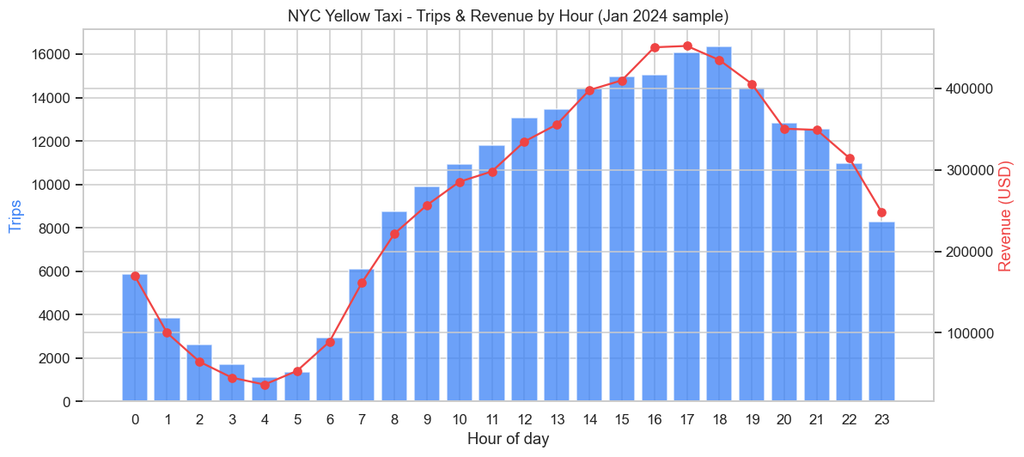

```python
# 6.1 Trips & Revenue by hour
fig, ax1 = plt.subplots()
ax2 = ax1.twinx()
ax1.bar(gold_hour["hour"], gold_hour["trips"], color="#3b82f6", alpha=0.75, label="Trips")
ax2.plot(gold_hour["hour"], gold_hour["revenue"], color="#ef4444", marker="o", label="Revenue ($)")
ax1.set_xlabel("Hour of day")
ax1.set_ylabel("Trips", color="#3b82f6")
ax2.set_ylabel("Revenue (USD)", color="#ef4444")
ax1.set_xticks(range(0, 24))
plt.title("NYC Yellow Taxi - Trips & Revenue by Hour (Jan 2024 sample)")
fig.tight_layout()
plt.savefig(f"{VIZ_DIR}/01_trips_revenue_by_hour.png", dpi=140, bbox_inches="tight")
plt.show()
```

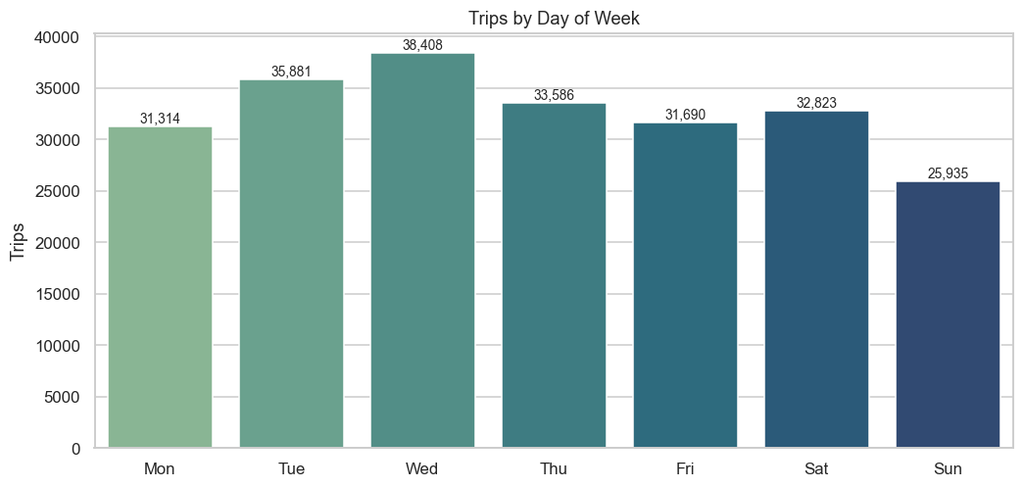

```python
# 6.2 Day-of-week
order = ["Mon","Tue","Wed","Thu","Fri","Sat","Sun"]
g = gold_dow.set_index("day").reindex(order).reset_index()
fig, ax = plt.subplots()
sns.barplot(data=g, x="day", y="trips", ax=ax, palette="crest")
ax.set_title("Trips by Day of Week")
ax.set_ylabel("Trips")
ax.set_xlabel("")
for i, v in enumerate(g["trips"]):
    ax.text(i, v, f"{int(v):,}", ha="center", va="bottom", fontsize=9)
plt.savefig(f"{VIZ_DIR}/02_trips_by_dow.png", dpi=140, bbox_inches="tight")
plt.show()
```

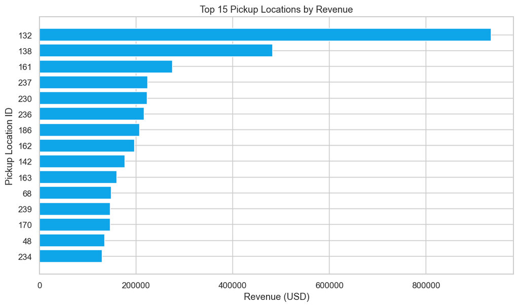

```python
# 6.3 Top pickup locations
fig, ax = plt.subplots(figsize=(11, 6))
top = gold_pu.sort_values("revenue", ascending=True)
ax.barh(top["PULocationID"].astype(str), top["revenue"], color="#0ea5e9")
ax.set_title("Top 15 Pickup Locations by Revenue")
ax.set_xlabel("Revenue (USD)")
ax.set_ylabel("Pickup Location ID")
plt.savefig(f"{VIZ_DIR}/03_top_pickups.png", dpi=140, bbox_inches="tight")
plt.show()
```

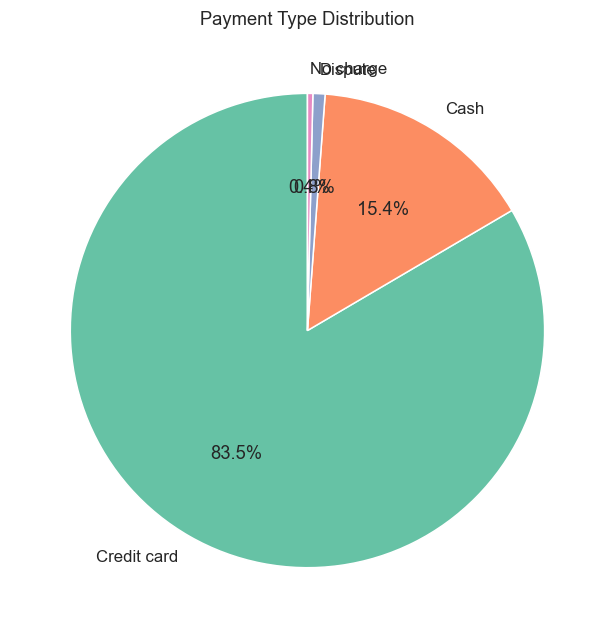

```python
# 6.4 Payment-type pie
fig, ax = plt.subplots(figsize=(7, 7))
ax.pie(gold_pay["trips"], labels=gold_pay["label"], autopct="%1.1f%%",
       startangle=90, colors=sns.color_palette("Set2"))
ax.set_title("Payment Type Distribution")
plt.savefig(f"{VIZ_DIR}/04_payment_mix.png", dpi=140, bbox_inches="tight")
plt.show()
```

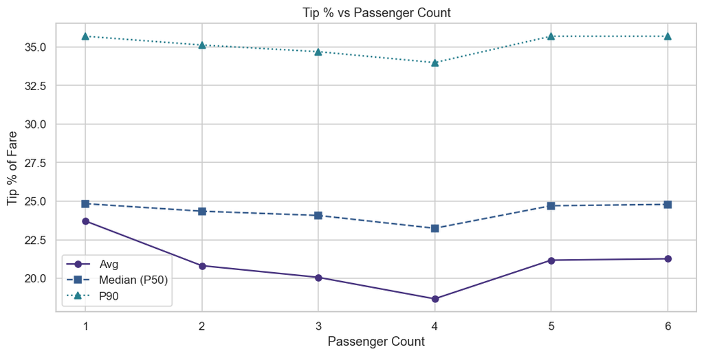

```python
# 6.5 Tip % by passenger count
fig, ax = plt.subplots()
x = gold_tip["passenger_count"].astype(int)
ax.plot(x, gold_tip["avg_tip_pct"], marker="o", label="Avg")
ax.plot(x, gold_tip["p50_tip_pct"], marker="s", linestyle="--", label="Median (P50)")
ax.plot(x, gold_tip["p90_tip_pct"], marker="^", linestyle=":",  label="P90")
ax.set_title("Tip % vs Passenger Count")
ax.set_xlabel("Passenger Count")
ax.set_ylabel("Tip % of Fare")
ax.legend()
plt.savefig(f"{VIZ_DIR}/05_tip_by_passengers.png", dpi=140, bbox_inches="tight")
plt.show()
```

## 8. Production-Readiness Notes

- **Indexes** on `tpep_pickup_datetime` and `PULocationID` keep aggregations fast.
- **`$out`** persists each Gold collection so dashboards (Tableau, Charts) can read pre-aggregated data without recomputing.
- For full-volume processing, MongoDB **sharding** on `tpep_pickup_datetime` (hashed) would distribute the ingest evenly; pipelines would run on each shard in parallel.

```python
print("Pipeline complete.")
print("Collections in nyc_taxi_dw:", db.list_collection_names())
```

```
Pipeline complete.
Collections in nyc_taxi_dw: ['taxi_gold_by_hour', 'taxi_bronze', 'taxi_silver', 'taxi_gold_tip_by_pax', 'taxi_gold_top_pickups', 'taxi_gold_by_dow', 'taxi_gold_by_payment']
```